# SF Salaries_Project

## Contents

### Import Libraries

```python
import pandas as pd
import numpy as np
import seaborn as sns
import matplotlib.pyplot as plt
%matplotlib inline
plt.style.use('fivethirtyeight')
import warnings
warnings.filterwarnings('ignore')
```

### San Francisco Salaries EDA

#### Brief info on dataset

```
* This data contains the names, job title, and compensation for San Francisco city employees on an annual basis from    2011 to 2014.
* We can observe -
    * How salaries have changed over time between different jobs
    * Number of Jobs per Year.
    * The average salary of employees per year.
    * The top 5 most common jobs.
    * Compare Jobs with high salaries and TotalPay(with overtimepay etc).
    * Compare Jobs with high salaries and TotalPayBenefits.
    * Compare high OvertimePaying Jobs.
```

### Data Cleaning

#### Reading and Viewing csv file

```python
# read dataset
sal = pd.read_csv('Salaries.csv')
```

```python
# view first 5 entries in dataset
sal.head()
```

|  | Id | EmployeeName | JobTitle | BasePay | OvertimePay | OtherPay | Benefits | TotalPay | TotalPayBenefits | Year | Notes | Agency | Status |
| --- | --- | --- | --- | --- | --- | --- | --- | --- | --- | --- | --- | --- | --- |
| 0 | 1 | NATHANIEL FORD | GENERAL MANAGER-METROPOLITAN TRANSIT AUTHORITY | 167411.18 | 0.00 | 400184.25 | NaN | 567595.43 | 567595.43 | 2011 | NaN | San Francisco | NaN |
| 1 | 2 | GARY JIMENEZ | CAPTAIN III (POLICE DEPARTMENT) | 155966.02 | 245131.88 | 137811.38 | NaN | 538909.28 | 538909.28 | 2011 | NaN | San Francisco | NaN |
| 2 | 3 | ALBERT PARDINI | CAPTAIN III (POLICE DEPARTMENT) | 212739.13 | 106088.18 | 16452.60 | NaN | 335279.91 | 335279.91 | 2011 | NaN | San Francisco | NaN |
| 3 | 4 | CHRISTOPHER CHONG | WIRE ROPE CABLE MAINTENANCE MECHANIC | 77916.00 | 56120.71 | 198306.90 | NaN | 332343.61 | 332343.61 | 2011 | NaN | San Francisco | NaN |
| 4 | 5 | PATRICK GARDNER | DEPUTY CHIEF OF DEPARTMENT,(FIRE DEPARTMENT) | 134401.60 | 9737.00 | 182234.59 | NaN | 326373.19 | 326373.19 | 2011 | NaN | San Francisco | NaN |

#### Check info of dataset

```python
# Check info of dataset

sal.info()
```

```
<class 'pandas.core.frame.DataFrame'>
RangeIndex: 148654 entries, 0 to 148653
Data columns (total 13 columns):
 #   Column            Non-Null Count   Dtype
---  ------            --------------   -----
 0   Id                148654 non-null  int64
 1   EmployeeName      148654 non-null  object
 2   JobTitle          148654 non-null  object
 3   BasePay           148045 non-null  float64
 4   OvertimePay       148650 non-null  float64
 5   OtherPay          148650 non-null  float64
 6   Benefits          112491 non-null  float64
 7   TotalPay          148654 non-null  float64
 8   TotalPayBenefits  148654 non-null  float64
 9   Year              148654 non-null  int64
 10  Notes             0 non-null       float64
 11  Agency            148654 non-null  object
 12  Status            0 non-null       float64
dtypes: float64(8), int64(2), object(3)
memory usage: 14.7+ MB
```

```python
# check the shape of dataset (rows,columns)

sal.shape
```

```
(148654, 13)
```

```python
# Check names of columns

sal.columns
```

```
Index(['Id', 'EmployeeName', 'JobTitle', 'BasePay', 'OvertimePay', 'OtherPay',
       'Benefits', 'TotalPay', 'TotalPayBenefits', 'Year', 'Notes', 'Agency',
       'Status'],
      dtype='object')
```

#### count number of filled entries in selected columns

```python
# count number of filled entries in columns
print(sal['Notes'].notnull().sum())
print(sal['Status'].notnull().sum())
```

```
0
0
```

```python
# Drop empty columns (Notes and Status columns)

sal.drop(columns = 'Notes', inplace=True)
sal.drop(columns = 'Status', inplace=True)
```

#### Check for duplicates

```python
# Check for duplicates

sal.duplicated().sum()
```

```
0
```

#### Check for null values

```python
# Check for null values

sal.isnull().sum()
```

```
Id                      0
EmployeeName            0
JobTitle                0
BasePay               609
OvertimePay             4
OtherPay                4
Benefits            36163
TotalPay                0
TotalPayBenefits        0
Year                    0
Agency                  0
dtype: int64
```

#### View rows with null or nan values

```python
# Function to bring out rows and columns with nan or null values

def check_null(col_name):
    checked = sal.loc[sal[col_name].isnull()]
    return checked

check_null('OvertimePay')
```

|  | Id | EmployeeName | JobTitle | BasePay | OvertimePay | OtherPay | Benefits | TotalPay | TotalPayBenefits | Year | Agency |
| --- | --- | --- | --- | --- | --- | --- | --- | --- | --- | --- | --- |
| 148646 | 148647 | Not provided | Not provided | NaN | NaN | NaN | NaN | 0.0 | 0.0 | 2014 | San Francisco |
| 148650 | 148651 | Not provided | Not provided | NaN | NaN | NaN | NaN | 0.0 | 0.0 | 2014 | San Francisco |
| 148651 | 148652 | Not provided | Not provided | NaN | NaN | NaN | NaN | 0.0 | 0.0 | 2014 | San Francisco |
| 148652 | 148653 | Not provided | Not provided | NaN | NaN | NaN | NaN | 0.0 | 0.0 | 2014 | San Francisco |

```python
# Check null for 'Otherpay' column

check_null('OtherPay')
```

|  | Id | EmployeeName | JobTitle | BasePay | OvertimePay | OtherPay | Benefits | TotalPay | TotalPayBenefits | Year | Agency |
| --- | --- | --- | --- | --- | --- | --- | --- | --- | --- | --- | --- |
| 148646 | 148647 | Not provided | Not provided | NaN | NaN | NaN | NaN | 0.0 | 0.0 | 2014 | San Francisco |
| 148650 | 148651 | Not provided | Not provided | NaN | NaN | NaN | NaN | 0.0 | 0.0 | 2014 | San Francisco |
| 148651 | 148652 | Not provided | Not provided | NaN | NaN | NaN | NaN | 0.0 | 0.0 | 2014 | San Francisco |
| 148652 | 148653 | Not provided | Not provided | NaN | NaN | NaN | NaN | 0.0 | 0.0 | 2014 | San Francisco |

```python
# Check null for 'Basepay' column

x = check_null('BasePay')
x.sample(5)
```

|  | Id | EmployeeName | JobTitle | BasePay | OvertimePay | OtherPay | Benefits | TotalPay | TotalPayBenefits | Year | Agency |
| --- | --- | --- | --- | --- | --- | --- | --- | --- | --- | --- | --- |
| 106971 | 106972 | Teresa V Lewkowitz | Assistant Recreation Director | NaN | 0.0 | 0.00 | 7959.18 | 0.00 | 7959.18 | 2013 | San Francisco |
| 106180 | 106181 | Michael S Costakis | Automotive Service Worker | NaN | 0.0 | 9335.22 | 0.00 | 9335.22 | 9335.22 | 2013 | San Francisco |
| 109985 | 109986 | Sahlu Wolde-Tsion | Engineer | NaN | 0.0 | 682.04 | 26.31 | 682.04 | 708.35 | 2013 | San Francisco |
| 108992 | 108993 | Betty C Tsang | Custodian | NaN | 0.0 | 2152.00 | 389.30 | 2152.00 | 2541.30 | 2013 | San Francisco |
| 106814 | 106815 | Roy L Norwood | Transit Operator | NaN | 0.0 | 0.00 | 7959.18 | 0.00 | 7959.18 | 2013 | San Francisco |

#### Replace missing values with 0 for selected columns

```python
# Replace missing values with 0 for column 'BasePay' and 'Benefits'

sal['BasePay'] = sal['BasePay'].fillna(0)

sal['Benefits'] = sal['Benefits'].fillna(0)
```

```python
# Fill in correct values for 'BasePay' and 'Benefits column'

sal['BasePay'] = sal['TotalPay'] - sal['OtherPay'] - sal['OvertimePay']

sal['Benefits'] = sal['TotalPayBenefits'] - sal['TotalPay']
```

```python
# check for null values update

sal.isnull().sum()
```

```
Id                  0
EmployeeName        0
JobTitle            0
BasePay             4
OvertimePay         4
OtherPay            4
Benefits            0
TotalPay            0
TotalPayBenefits    0
Year                0
Agency              0
dtype: int64
```

#### Removing Unneeded rows

```python
# Removing rows where values are nan or not provided for Overtime pay and Otherpay columns

sal = sal[sal['EmployeeName'] != 'Not provided']
```

```python
# remove rows where selected columns are == 0, since they arent needed for analysis

remove_rows = sal[(sal['TotalPay'] == 0) & (sal['BasePay'] == 0) & (sal['OvertimePay'] == 0) & (sal['OtherPay'] == 0)
         & (sal['Benefits'] == 0) & (sal['TotalPayBenefits'] == 0) ]

sal = sal[~sal.index.isin(remove_rows.index)]
```

```python
#check for duplicates in name regardless of case
#duplicates = sal['EmployeeName'].str.lower().duplicated()
```

```python
# check for updates

sal.isnull().sum()
```

```
Id                  0
EmployeeName        0
JobTitle            0
BasePay             0
OvertimePay         0
OtherPay            0
Benefits            0
TotalPay            0
TotalPayBenefits    0
Year                0
Agency              0
dtype: int64
```

#### View Statistical summary

```python
# check the Statistical summary for numerical columns

sal.describe()
```

|  | Id | BasePay | OvertimePay | OtherPay | Benefits | TotalPay | TotalPayBenefits | Year |
| --- | --- | --- | --- | --- | --- | --- | --- | --- |
| count | 148624.000000 | 148624.000000 | 148624.000000 | 148624.000000 | 148624.000000 | 148624.000000 | 148624.000000 | 148624.000000 |
| mean | 74314.770367 | 66067.062343 | 5066.946133 | 3649.405605 | 18928.052727 | 74783.414081 | 93711.466808 | 2012.522406 |
| std | 42905.154430 | 42880.769285 | 11455.186420 | 8057.161986 | 17164.905825 | 50510.932452 | 62785.758548 | 1.117452 |
| min | 1.000000 | -166.010000 | -0.010000 | -7058.590000 | -33.890000 | -618.130000 | -618.130000 | 2011.000000 |
| 25% | 37159.750000 | 32840.870000 | 0.000000 | 0.000000 | 0.000000 | 36191.340000 | 44129.167500 | 2012.000000 |
| 50% | 74315.500000 | 64872.330000 | 0.000000 | 812.290000 | 23236.325000 | 71432.885000 | 92417.345000 | 2013.000000 |
| 75% | 111471.250000 | 94611.002500 | 4658.937500 | 4237.620000 | 33470.220000 | 105848.182500 | 132884.875000 | 2014.000000 |
| max | 148654.000000 | 319275.010000 | 245131.880000 | 400184.250000 | 96570.660000 | 567595.430000 | 567595.430000 | 2014.000000 |

```python
sal[sal['BasePay'] == -166.01]
```

|  | Id | EmployeeName | JobTitle | BasePay | OvertimePay | OtherPay | Benefits | TotalPay | TotalPayBenefits | Year | Agency |
| --- | --- | --- | --- | --- | --- | --- | --- | --- | --- | --- | --- |
| 72832 | 72833 | Irwin Sidharta | Junior Clerk | -166.01 | 249.02 | 0.0 | 6.56 | 83.01 | 89.57 | 2012 | San Francisco |

- Negative Basepay salary, indicating not a full time employee, but probably a contractor that spent more than he was meant to for the job or is owing the company.

##### ----------Dataset is Fully Cleaned------------

## Salaries Exploratory Data Analysis (EDA)

```python
# view dataset

sal.head()
```

|  | Id | EmployeeName | JobTitle | BasePay | OvertimePay | OtherPay | Benefits | TotalPay | TotalPayBenefits | Year | Agency |
| --- | --- | --- | --- | --- | --- | --- | --- | --- | --- | --- | --- |
| 0 | 1 | NATHANIEL FORD | GENERAL MANAGER-METROPOLITAN TRANSIT AUTHORITY | 167411.18 | 0.00 | 400184.25 | 0.0 | 567595.43 | 567595.43 | 2011 | San Francisco |
| 1 | 2 | GARY JIMENEZ | CAPTAIN III (POLICE DEPARTMENT) | 155966.02 | 245131.88 | 137811.38 | 0.0 | 538909.28 | 538909.28 | 2011 | San Francisco |
| 2 | 3 | ALBERT PARDINI | CAPTAIN III (POLICE DEPARTMENT) | 212739.13 | 106088.18 | 16452.60 | 0.0 | 335279.91 | 335279.91 | 2011 | San Francisco |
| 3 | 4 | CHRISTOPHER CHONG | WIRE ROPE CABLE MAINTENANCE MECHANIC | 77916.00 | 56120.71 | 198306.90 | 0.0 | 332343.61 | 332343.61 | 2011 | San Francisco |
| 4 | 5 | PATRICK GARDNER | DEPUTY CHIEF OF DEPARTMENT,(FIRE DEPARTMENT) | 134401.60 | 9737.00 | 182234.59 | 0.0 | 326373.19 | 326373.19 | 2011 | San Francisco |

#### What is the Average BasePay for all Jobs ?

```python
# get the average basepay
round(sal['BasePay'].mean())
```

```
66067
```

- The Average BasePay through years 2011 - 2014 is approximately 66,100 For all Jobs

#### What is the highest amount of OvertimePay for all Jobs?

```python
# Get the row with the maximum value for 'OvertimePay'

round(sal['OvertimePay'].max())
```

```
245132
```

#### What are the details of the employee with the most overtimepay?

```python
# Get the row with the maximum value for 'OvertimePay'

sal.loc[sal['OvertimePay'].idxmax()].to_frame()
```

|  | 1 |
| --- | --- |
| Id | 2 |
| EmployeeName | GARY JIMENEZ |
| JobTitle | CAPTAIN III (POLICE DEPARTMENT) |
| BasePay | 155966.02 |
| OvertimePay | 245131.88 |
| OtherPay | 137811.38 |
| Benefits | 0.0 |
| TotalPay | 538909.28 |
| TotalPayBenefits | 538909.28 |
| Year | 2011 |
| Agency | San Francisco |

- This Shows the details of the Employee and job title earning the most overtime pay

#### What is the job title of JOSEPH DRISCOLL ?

```python
# Method 1

sal[sal['EmployeeName'] == 'JOSEPH DRISCOLL']['JobTitle']
```

```
24    CAPTAIN, FIRE SUPPRESSION
Name: JobTitle, dtype: object
```

```python
# Method 2

df = sal[sal['EmployeeName'] == 'JOSEPH DRISCOLL']
```

```python
df['JobTitle']
```

```
24    CAPTAIN, FIRE SUPPRESSION
Name: JobTitle, dtype: object
```

```python
# Method 3

sal[sal['EmployeeName'] == 'JOSEPH DRISCOLL']
```

|  | Id | EmployeeName | JobTitle | BasePay | OvertimePay | OtherPay | Benefits | TotalPay | TotalPayBenefits | Year | Agency |
| --- | --- | --- | --- | --- | --- | --- | --- | --- | --- | --- | --- |
| 24 | 25 | JOSEPH DRISCOLL | CAPTAIN, FIRE SUPPRESSION | 140546.86 | 97868.77 | 31909.28 | 0.0 | 270324.91 | 270324.91 | 2011 | San Francisco |

```python
# Method 1 for TotalPayBenefits

sal[sal['EmployeeName'] == 'JOSEPH DRISCOLL']['TotalPayBenefits']
```

```
24    270324.91
Name: TotalPayBenefits, dtype: float64
```

#### What is the name of highest paid person (including benefits)?

```python
# Method 1

df2 = sal.loc[sal['TotalPayBenefits'].idxmax()]
```

```python
df2['EmployeeName']
```

```
'NATHANIEL FORD'
```

```python
# Method 2

sal.loc[sal['TotalPayBenefits'].idxmax()]['EmployeeName']
```

```
'NATHANIEL FORD'
```

```python
# Get the row with the highest paid person

sal.loc[sal['TotalPayBenefits'].idxmax()].to_frame()
```

|  | 0 |
| --- | --- |
| Id | 1 |
| EmployeeName | NATHANIEL FORD |
| JobTitle | GENERAL MANAGER-METROPOLITAN TRANSIT AUTHORITY |
| BasePay | 167411.18 |
| OvertimePay | 0.0 |
| OtherPay | 400184.25 |
| Benefits | 0.0 |
| TotalPay | 567595.43 |
| TotalPayBenefits | 567595.43 |
| Year | 2011 |
| Agency | San Francisco |

- This shows details of the highest paid person including benefits

#### What is the name of lowest paid person (including benefits)? Do you notice something strange about how much he or she is paid?

```python
# Method 1

sal.loc[sal['TotalPayBenefits'].idxmin()]['EmployeeName']
```

```
'Joe Lopez'
```

```python
# Get the row with the lowest paid person
sal.loc[sal['TotalPayBenefits'].idxmin()].to_frame()
```

|  | 148653 |
| --- | --- |
| Id | 148654 |
| EmployeeName | Joe Lopez |
| JobTitle | Counselor, Log Cabin Ranch |
| BasePay | 0.0 |
| OvertimePay | 0.0 |
| OtherPay | -618.13 |
| Benefits | 0.0 |
| TotalPay | -618.13 |
| TotalPayBenefits | -618.13 |
| Year | 2014 |
| Agency | San Francisco |

- Observation - This person is not a full time employee, but probably a contractor that spent more than he was meant to for the job or owes the company, hence the negative amount.

#### What was the average (mean) BasePay of all employees per year? (2011-2014) ?

```python
# get average basepay per year
avg_basepay = sal.groupby('Year')['BasePay'].mean().round().reset_index()
avg_basepay
```

|  | Year | BasePay |
| --- | --- | --- |
| 0 | 2011 | 63601.0 |
| 1 | 2012 | 65436.0 |
| 2 | 2013 | 68510.0 |
| 3 | 2014 | 66605.0 |

- This shows the average basepay as the years go by.

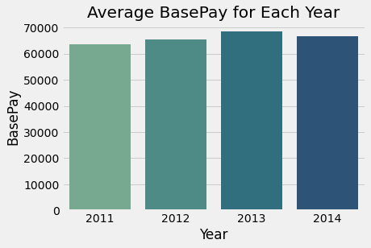

```python
# visualizing the average basepay per year

sns.barplot(x = 'Year', y = 'BasePay' , data = avg_basepay, palette = 'crest')
plt.title('Average BasePay for Each Year')
```

- This Bar chart shows us that, average Basepay increases over the years from 2011-2013 but we see a decrease in 2014.

#### How many unique job titles are there?

```python
sal['JobTitle'].nunique()
```

```
2158
```

#### What are the top 5 most common jobs?

```python
# get the unique jobs
common_jobs = sal['JobTitle'].value_counts().reset_index()
top_5 = common_jobs.head()
top_5
```

|  | index | JobTitle |
| --- | --- | --- |
| 0 | Transit Operator | 7036 |
| 1 | Special Nurse | 4389 |
| 2 | Registered Nurse | 3736 |
| 3 | Public Svc Aide-Public Works | 2518 |
| 4 | Police Officer 3 | 2421 |

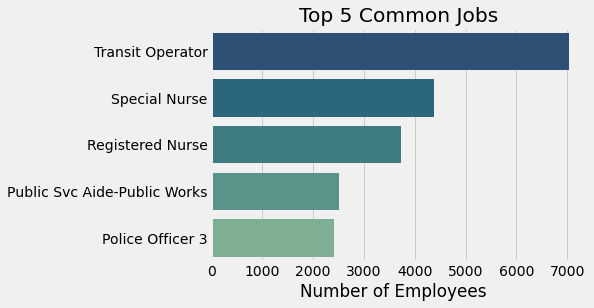

```python
# visualize top 5 most common jobs
sns.barplot(x = 'JobTitle' ,y = 'index',data = top_5, palette = 'crest_r')
plt.ylabel('')
plt.xlabel('Number of Employees  ')
plt.title('Top 5 Common Jobs')
```

#### What is the average basepay for the Top 5 most common jobs?

```python
# pass the top 5 jobs and year range into a list
jobs = top_5['index'].to_list()
year = [2011,2012,2013,2014]
```

```python
# Function to get the average basepay for the top 5 most common jobs from the list

def get_avgpay2(df, col, titles, avgcol, yearcol, years):
    if isinstance(titles, str):
        # if titles is a single string, convert it to a list
        titles = [titles]
    results = [] # create a results list
    for title in titles:
        # check if the job title is in the DataFrame, regardless of case
        if not any(df[col].str.lower() == title.lower()):
            print(f"Job title '{title}' not found in DataFrame") # prints if the job isnt found in the dataframe
            continue
        result = {'JobTitle': title}
        for year in years:
            avg_year = df[(df[col].str.lower() == title.lower()) & (df[yearcol] == year)][avgcol].mean() # get average of title column for given year
            result[str(year)] = avg_year # store average base pay for year in result dictionary

        avg = df[df[col].str.lower() == title.lower()][avgcol].mean() # get overall average of title column
        result['Avg_Total_basepay'] = avg # store job title and overall average base pay

        results.append(result) # add result dictionary to list
    return pd.DataFrame(results) # convert list of dictionaries to dataframe
```

```python
# call the function to get the average basepay over the years
get_avgpay2(sal, 'JobTitle', jobs, 'BasePay', 'Year', year)
```

|  | JobTitle | 2011 | 2012 | 2013 | 2014 | Avg_Total_basepay |
| --- | --- | --- | --- | --- | --- | --- |
| 0 | Transit Operator | 48701.657357 | 52227.817175 | 53928.593046 | 48086.056434 | 50659.199140 |
| 1 | Special Nurse | 28292.056569 | 29568.771678 | 30098.793917 | 29979.047409 | 29496.645117 |
| 2 | Registered Nurse | 94940.098925 | 97208.295020 | 106834.022892 | 103167.181329 | 100525.672553 |
| 3 | Public Svc Aide-Public Works | NaN | 7914.391252 | 7188.184191 | 9047.962358 | 8079.021620 |
| 4 | Police Officer 3 | NaN | 105673.789340 | 113000.230814 | 105811.051009 | 108060.464924 |

- Observations
  - This shows us that the Top 5 most common jobs with their average Basepay in total 4 years and broken down into individual years.
  - Police Officer 3 & Public Svc Aide-Public Works aren't available in the year 2011.

#### Visualizing the avg BasePay

```python
# setting variables to be used in plotting
to_plot = get_avgpay2(sal, 'JobTitle', jobs, 'BasePay', 'Year', year)
plot1 = to_plot[to_plot['JobTitle'] == 'Transit Operator'] # set for Transit Operator
plot2 = to_plot[to_plot['JobTitle'] == 'Special Nurse'] # set for Special Nurse'
plot3 = to_plot[to_plot['JobTitle'] == 'Registered Nurse'] # set for Registered Nurse
plot4 = to_plot[to_plot['JobTitle'] == 'Public Svc Aide-Public Works'] # set for Public Svc Aide-Public Works
plot5 = to_plot[to_plot['JobTitle'] == 'Police Officer 3'] # set for Police Officer 3
```

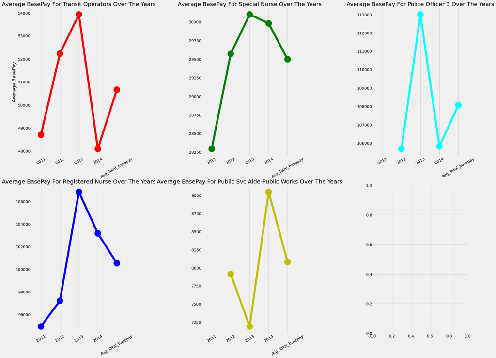

```python
# create a grid of subplots with 1 row and 2 columns
fig, axes = plt.subplots(nrows=2, ncols=3, figsize=(25, 20))

# plot the first graph in the first subplot
sns.pointplot(data=plot1, ax=axes[0,0], color = 'r')
axes[0,0].set_title("Average BasePay For Transit Operators Over The Years") # set title
axes[0,0].set_ylabel('Average BasePay') # set y axis label
axes[0,0].set_xticklabels(axes[0,0].get_xticklabels(),rotation=30) # set x axis ticks format
axes[0,0].grid() # type of plot

# plot the second graph in the second subplot
sns.pointplot(data=plot2, ax=axes[0,1], color = 'g')
axes[0,1].set_title("Average BasePay For Special Nurse Over The Years") # set title
axes[0,1].set_ylabel('') # set y axis label
axes[0,1].set_xticklabels(axes[0,1].get_xticklabels(),rotation=30) # set x axis ticks format
axes[0,1].grid() # type of plot

# plot the third graph in the third subplot
sns.pointplot(data=plot3, ax=axes[1,0], color = 'b')
axes[1,0].set_title("Average BasePay For Registered Nurse Over The Years") # set title
axes[1,0].set_ylabel('') # set y axis label
axes[1,0].set_xticklabels(axes[1,0].get_xticklabels(),rotation=30) # set x axis ticks format
axes[1,0].grid() # type of plot


# plot the third graph in the third subplot
sns.pointplot(data=plot4, ax=axes[1,1], color = 'y')
axes[1,1].set_title("Average BasePay For Public Svc Aide-Public Works Over The Years") # set title
axes[1,1].set_ylabel('') # set y axis label
axes[1,1].set_xticklabels(axes[1,1].get_xticklabels(),rotation=30) # set x axis ticks format
axes[1,1].grid() # type of plot

# plot the third graph in the third subplot
sns.pointplot(data=plot5, ax=axes[0,2], color = 'cyan')
axes[0,2].set_title("Average BasePay For Police Officer 3 Over The Years") # set title
axes[0,2].set_ylabel('') # set y axis label
axes[0,2].set_xticklabels(axes[0,2].get_xticklabels(),rotation=30) # set x axis ticks format
axes[0,2].grid() # type of plot

# adjust the spacing between subplots and display the plot
plt.subplots_adjust(wspace=0.8)
plt.show()
```

#### How many Job Titles were represented by only one person in 2013? (e.g. Job Titles with only one occurence in 2013?)

```python
# Method 1

sum(sal[sal['Year'] == 2013]['JobTitle'].value_counts()==1)
```

```
202
```

```python
# Method 2

# Select only the rows where 'Year' == 2013
Y2013 = sal[sal['Year'] == 2013]

# Count the number of occurrences of each value in the 'JobTitle' column
counts = Y2013['JobTitle'].value_counts()

# Select only the values that occur once
counts_once = counts[counts == 1]
```

```python
counts_once.value_counts()
```

```
1    202
Name: JobTitle, dtype: int64
```

- They were 202 single job entries in 2013

#### How many people have the word Chief in their job title?

```python
# Method 1

def chief_string(title):
    if 'chief' in title.lower():
        return True
    else:
        return False

sum(sal['JobTitle'].apply(chief_string))
```

```
627
```

```python
# Method 2

# Use str.contains() to select only the rows that contain the string 'Chief'
chief_rows = sal[sal['JobTitle'].str.contains('Chief', case = False)]

# Count the number of rows in chief_rows
num_chief_rows = len(chief_rows)

num_chief_rows
```

```
627
```

- WE have 627 Jobs that have Chief in their Title. For example Chief of Police

#### Is there a correlation between length of the Job Title string and Salary?

```python
# Method 1

sal['title_len'] = sal['JobTitle'].apply(len)
sal[['title_len','TotalPay']].corr()
```

|  | title_len | TotalPay |
| --- | --- | --- |
| title_len | 1.000000 | -0.015441 |
| TotalPay | -0.015441 | 1.000000 |

```python
# Create new columns that contain the lengths of the 'JobTitle' and 'BasePay' columns
sal['JobTitleLength'] = sal['JobTitle'].str.len()
sal['TotalPayLength'] = sal['TotalPay'].astype(str).str.len()

# Use the corr() method to calculate the correlation coefficient between the new columns
corr = sal[['JobTitleLength', 'TotalPayLength']].corr()
corr
```

|  | JobTitleLength | TotalPayLength |
| --- | --- | --- |
| JobTitleLength | 1.000000 | -0.059357 |
| TotalPayLength | -0.059357 | 1.000000 |

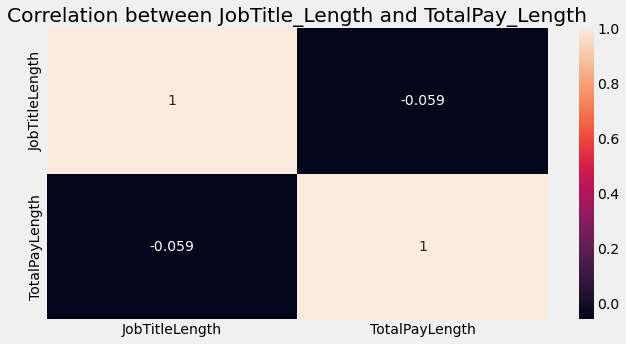

```python
# view correlation with heatmap
plt.figure(figsize=(10,5))
sns.heatmap(corr,annot=True)
plt.title('Correlation between JobTitle_Length and TotalPay_Length')
```

- With this Heatmap visual We see that we have no Correlation between Job Title string and Salary.

### Extra Visuals

```python
# view dataset
sal.head(2)
```

|  | Id | EmployeeName | JobTitle | BasePay | OvertimePay | OtherPay | Benefits | TotalPay | TotalPayBenefits | Year | Agency | title_len | JobTitleLength | TotalPayLength |
| --- | --- | --- | --- | --- | --- | --- | --- | --- | --- | --- | --- | --- | --- | --- |
| 0 | 1 | NATHANIEL FORD | GENERAL MANAGER-METROPOLITAN TRANSIT AUTHORITY | 167411.18 | 0.00 | 400184.25 | 0.0 | 567595.43 | 567595.43 | 2011 | San Francisco | 46 | 46 | 9 |
| 1 | 2 | GARY JIMENEZ | CAPTAIN III (POLICE DEPARTMENT) | 155966.02 | 245131.88 | 137811.38 | 0.0 | 538909.28 | 538909.28 | 2011 | San Francisco | 31 | 31 | 9 |

#### Count Number of Jobs per Year

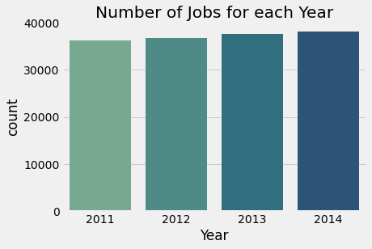

```python
# count the number of jobs in each year on the dataset
sns.countplot(x = sal['Year'], palette = 'crest')
plt.title('Number of Jobs for each Year')
```

- We can see that the number of job entries increase as the year increases

#### Compare Most BasePaying Jobs with TotalPay

```python
# Get Top 5 Most Paid Employees with Benefits

mostpaid = sal[['EmployeeName','JobTitle','BasePay','TotalPay']].sort_values(by='BasePay',ascending=False)
mostpaid.head(5)
```

|  | EmployeeName | JobTitle | BasePay | TotalPay |
| --- | --- | --- | --- | --- |
| 72925 | Gregory P Suhr | Chief of Police | 319275.01 | 339282.07 |
| 110532 | Amy P Hart | Asst Med Examiner | 318835.49 | 390111.98 |
| 72929 | Robert L Shaw | Dep Dir for Investments, Ret | 315572.01 | 315572.01 |
| 72926 | Joanne M Hayes-White | Chief, Fire Department | 313686.01 | 336922.01 |
| 72931 | Harlan L Kelly-Jr | Executive Contract Employee | 313312.52 | 313312.52 |

```python
# Get Top 5 Most Paying Jobs

mostpaid = sal[['JobTitle','BasePay']].sort_values(by='BasePay',ascending=False)
mostpaid1 = mostpaid.head(5)

# Get Top 5 Most Paying Jobs

mostpaidB = sal[['JobTitle','TotalPay']].sort_values(by='TotalPay',ascending=False)
mostpaid2 = mostpaidB.head(5)
```

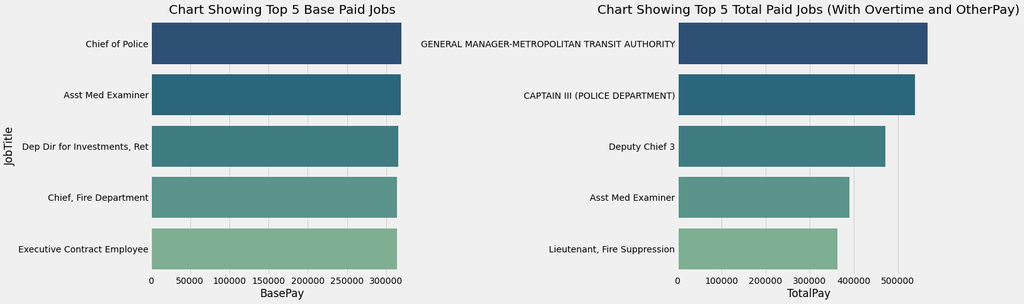

```python
# create a grid of subplots with 1 row and 2 columns
fig, axes = plt.subplots(nrows=1, ncols=2, figsize=(20, 7))

# plot the first graph in the first subplot
sns.barplot(x = 'BasePay', y = 'JobTitle', data=mostpaid1 , ax=axes[0], palette='crest_r')
axes[0].set_title("Chart Showing Top 5 Base Paid Jobs")


# plot the second graph in the second subplot
sns.barplot(x = 'TotalPay', y = 'JobTitle', data=mostpaid2, ax=axes[1], palette='crest_r')
axes[1].set_title("Chart Showing Top 5 Total Paid Jobs (With Overtime and OtherPay)")
axes[1].set_ylabel('')

# adjust the spacing between subplots and display the plot
plt.subplots_adjust(wspace=1)
plt.show()
```

- Observation -
  - There is a huge differnce between the BasePay for Jobs and the TotalPay.
  - Because the basepay is what you get as your initial effort for the job.
  - While the totalpay is your basepay + your overtimepay + other work related pay.
  - Hence Totalpay is gotten and can be higher depending on extra effort put into work.

#### Compare Least Paying Jobs with added benefits

```python
# Get Top 5 Least Paying Jobs

leastpaid = sal[['JobTitle','BasePay']].sort_values(by='BasePay',ascending=True)
leastpaid1 = leastpaid.head(5)

leastpaidB = sal[['JobTitle','TotalPayBenefits']].sort_values(by='TotalPayBenefits',ascending=True)
leastpaid2 = leastpaidB.head(5)
```

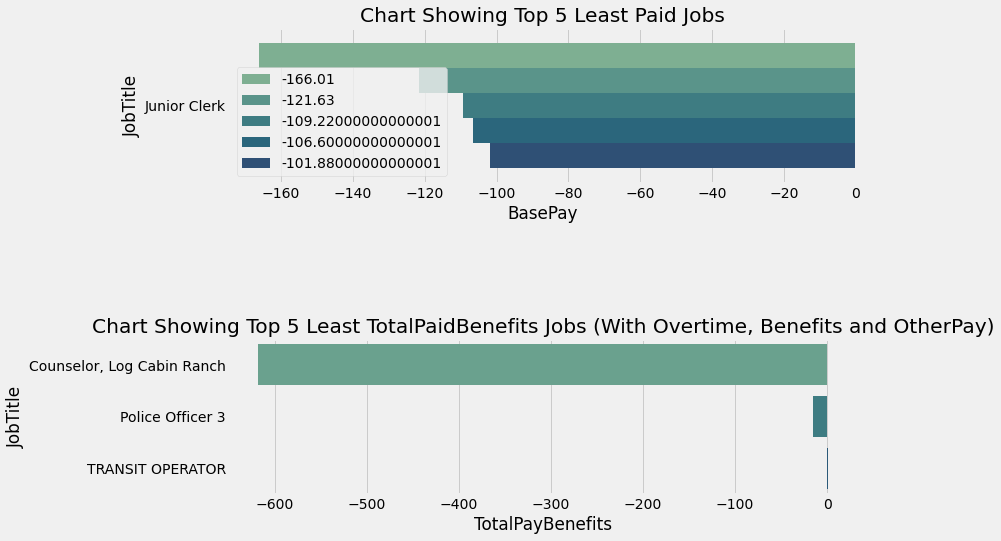

```python
# create a grid of subplots with 1 row and 2 columns
fig, axes = plt.subplots(nrows=2, ncols=1, figsize=(10, 8))

# plot the first graph in the first subplot
sns.barplot(x = 'BasePay', y = 'JobTitle', data=leastpaid1 , ax=axes[0], hue='BasePay', palette='crest')
axes[0].set_title("Chart Showing Top 5 Least Paid Jobs")
axes[0].legend(loc=3)

# plot the second graph in the second subplot
sns.barplot(x = 'TotalPayBenefits', y = 'JobTitle', data=leastpaid2 , ax=axes[1],ci=0 ,palette='crest')
axes[1].set_title("Chart Showing Top 5 Least TotalPaidBenefits Jobs (With Overtime, Benefits and OtherPay)")

# adjust the spacing between subplots and display the plot
plt.subplots_adjust(hspace=1)
plt.show()
```

- Observation - This least paying jobs are probably those who probably owing the company even with overtime and benefits, hence the negative values.

#### Most OvertimePaying Jobs

```python
# Get Top 5 Most overtimePaying Jobs

overt_paid = sal[['JobTitle','OvertimePay']].sort_values(by='OvertimePay',ascending=False).head(5)
```

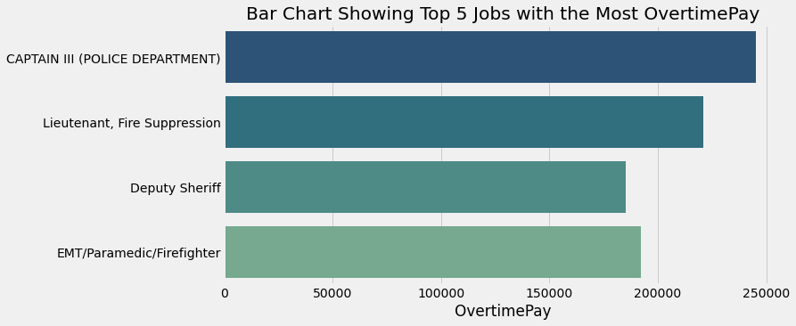

```python
# Plot graph for 5 Most overtimePaying Jobs

plt.figure(figsize=(10,5))
sns.barplot(x = 'OvertimePay', y = 'JobTitle', data = overt_paid, ci=0, palette='crest_r' )
plt.ylabel('')
plt.title('Bar Chart Showing Top 5 Jobs with the Most OvertimePay')
```

- This shows the jobs with high overtime pay, basepay aside and Captain III of police department earns the highest overtimepay

```python
# Get Top 5 Most Jobs with highest Benefits

benefits = sal[['JobTitle','Benefits']].sort_values(by='Benefits',ascending=False).reset_index()
benefits1 = benefits.head(5)

benefits2 = benefits.tail(5)
```

#### Compare Jobs with high Benefits

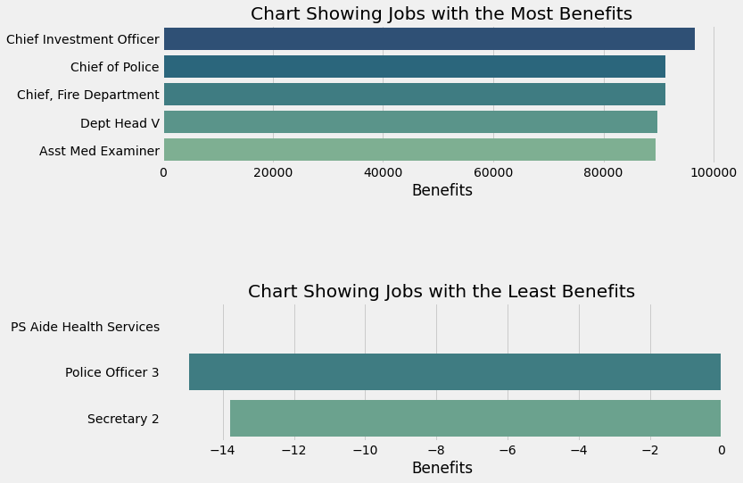

```python
# create a grid of subplots with 1 row and 2 columns
fig, axes = plt.subplots(nrows=2, ncols=1, figsize=(10, 8))

# plot the first graph in the first subplot
sns.barplot(x = 'Benefits', y = 'JobTitle', data=benefits1 , ax=axes[0], palette='crest_r')
axes[0].set_title("Chart Showing Jobs with the Most Benefits")
axes[0].set_ylabel('')


# plot the second graph in the second subplot
sns.barplot(x = 'Benefits', y = 'JobTitle', data=benefits2 , ax=axes[1],ci=0 ,palette='crest_r')
axes[1].set_title("Chart Showing Jobs with the Least Benefits")
axes[1].set_ylabel('')

# adjust the spacing between subplots and display the plot
plt.subplots_adjust(hspace=1)
plt.show()
```

- Observations
  - This compares the most and least jobs with their benefits.
  - The Chief investment officer earns more benefits.
  - negative benefits probably mean they were taxed money due to a problem e.g(breaking of office equipment) or they owe the company.

### Decision

- Looking for high benefits? take a job as a chief investment officer
- Like working overtime? with good pay?. Take a job as the Captain III of police
- Like working with good pay, benefits or not and without extra effort? Then take a job as the General Manager of Transit Authority
- Looking for a community based job with lots of people in it? then take a job as a Transit Operator